# PA1_template

Jeet Tanna

July 16, 2020

### **This is an R Markdown document of the 1st project in the reproducible research course on Coursera.**

**1. First Ill start off by improting the data which is stored in a csv file and Ill store it in a variable named data.**

```r
data<-read.csv("C:/Users/JeetsPC-1/Desktop/Study Material/R DataSets/activity.csv")
data$date=as.Date(data$date)
```

**2. Now that the data has been imported, I’ll make a histogram of total number of steps taken each day. I’ll store the number of steps each day in a vecor variable “steps”**

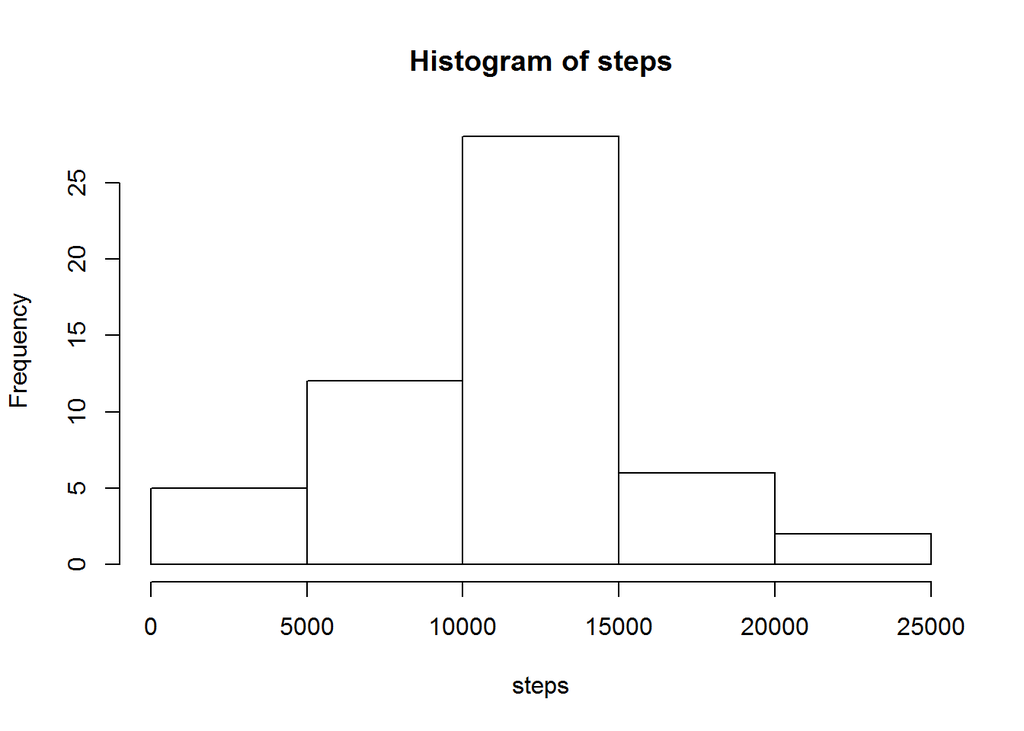

```r
steps<-tapply(data$steps,data$date,sum)
hist(steps)
```

Therefore by looking at this histogram we can say that it has a normal distribution and the user takes between 10000-15000 steps on an average days. The user took 10000-15000 steps on 25+ days.

**3. Now we’ll calculate the mean and median number of steps taken each day from the variable steps**

```r
mean(steps,na.rm = TRUE)
```

```
## [1] 10766.19
```

```r
median(steps,na.rm = TRUE)
```

```
## [1] 10765
```

**4. Now We’ll make a time series plot of the average number of steps taken by using the plot function**

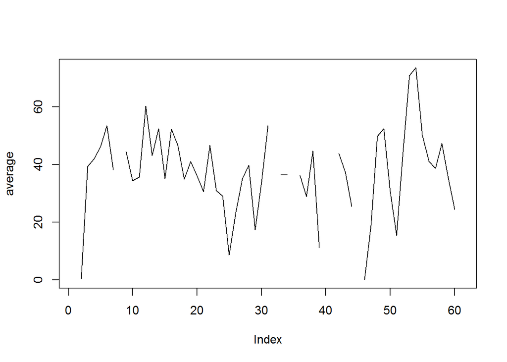

```r
average<-tapply(data$steps,data$date,mean)
plot(average,type = "l")
```

```r
library(lubridate)
library(zoo)
data$datetime= as.POSIXct(data$date+minutes(data$interval))
data$interval<-factor(data$interval)
maxint<-aggregate(data=data,steps~date+interval,FUN="mean")
maxint2<-aggregate(data=maxint,steps~interval,FUN="max")
max(maxint2$steps)
```

```
## [1] 806
```

```r
data1<-na.omit(data)
data1$date<-as.Date(data1$date)
```

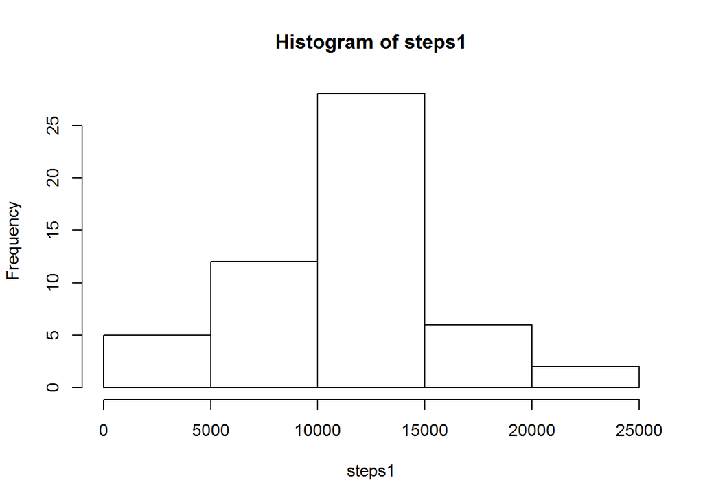

```r
data1<-na.omit(data)
steps1<-tapply(data1$steps,data1$date,sum)
hist(steps1)
```

Again the histogram indicated that the user usually takes between 10000-15000 days on an average day. The least occurance is of the user taking over 20000 steps which only happened on 2 days.

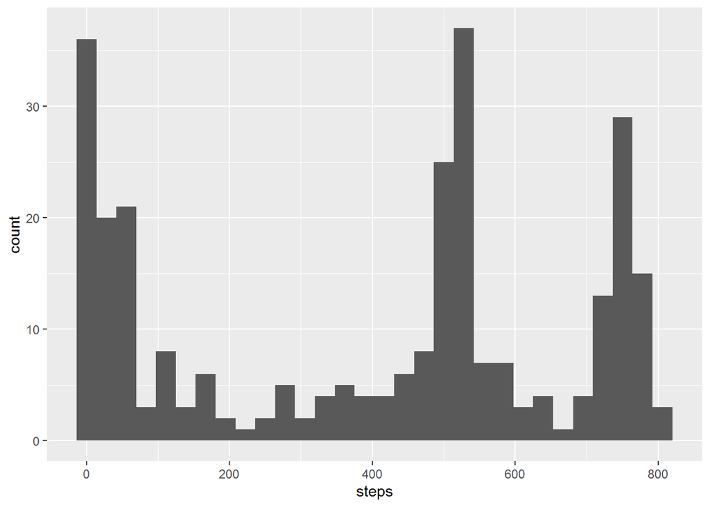

```r
data1$weekday<-weekdays(data1$date)
data1$isweekday<-ifelse(data1$weekday=="Friday"|data1$weekday=="Saturday"|data1$weekday=="Sunday","weekend","weekday")
library(ggplot2)
data$interval<-factor(data$interval)
maxinterval<-aggregate(data=data1,steps~date+interval,FUN="mean")
maxinterval2<-aggregate(data=maxinterval,steps~interval,FUN="max")

ggplot(maxinterval2,aes(steps))+geom_histogram()
```